# Lab3_Wakerley

Author

Kyle Wakerley

```r
met = read.csv("C:/Users/kylew/Downloads/met_all.gz")
library(dplyr)
```

```r
dim(met)
```

```
[1] 2377343      30
```

There are 2377343 rows and 30 columns in the meteorological data set.

```r
str(met)
```

```
'data.frame':   2377343 obs. of  30 variables:
 $ USAFID           : int  690150 690150 690150 690150 690150 690150 690150 690150 690150 690150 ...
 $ WBAN             : int  93121 93121 93121 93121 93121 93121 93121 93121 93121 93121 ...
 $ year             : int  2019 2019 2019 2019 2019 2019 2019 2019 2019 2019 ...
 $ month            : int  8 8 8 8 8 8 8 8 8 8 ...
 $ day              : int  1 1 1 1 1 1 1 1 1 1 ...
 $ hour             : int  0 1 2 3 4 5 6 7 8 9 ...
 $ min              : int  56 56 56 56 56 56 56 56 56 56 ...
 $ lat              : num  34.3 34.3 34.3 34.3 34.3 34.3 34.3 34.3 34.3 34.3 ...
 $ lon              : num  -116 -116 -116 -116 -116 ...
 $ elev             : int  696 696 696 696 696 696 696 696 696 696 ...
 $ wind.dir         : int  220 230 230 210 120 NA 320 10 320 350 ...
 $ wind.dir.qc      : chr  "5" "5" "5" "5" ...
 $ wind.type.code   : chr  "N" "N" "N" "N" ...
 $ wind.sp          : num  5.7 8.2 6.7 5.1 2.1 0 1.5 2.1 2.6 1.5 ...
```

[output cut: 16 more lines]

```r
summary(met[, c(3, 5, 6, 24, 10, 14)])
```

```
      year           day          hour            temp             elev
 Min.   :2019   Min.   : 1   Min.   : 0.00   Min.   :-40.00   Min.   : -13.0
 1st Qu.:2019   1st Qu.: 8   1st Qu.: 5.00   1st Qu.: 19.60   1st Qu.: 101.0
 Median :2019   Median :16   Median :11.00   Median : 23.50   Median : 252.0
 Mean   :2019   Mean   :16   Mean   :11.34   Mean   : 23.59   Mean   : 415.8
 3rd Qu.:2019   3rd Qu.:24   3rd Qu.:17.00   3rd Qu.: 27.80   3rd Qu.: 400.0
 Max.   :2019   Max.   :31   Max.   :23.00   Max.   : 56.00   Max.   :9999.0
                                             NA's   :60089
    wind.sp
 Min.   : 0.000
 1st Qu.: 0.000
 Median : 2.100
 Mean   : 2.459
 3rd Qu.: 3.600
 Max.   :36.000
 NA's   :79693
```

```r
met = met %>% mutate(elev = na_if(elev, 9999))
summary(met$elev)
```

```
   Min. 1st Qu.  Median    Mean 3rd Qu.    Max.    NA's
    -13     101     252     413     400    4113     710
```

```r
met = met %>% mutate(temp = na_if(temp, -40))
met = met %>% filter(!is.na(temp))
summary(met$temp)
```

```
   Min. 1st Qu.  Median    Mean 3rd Qu.    Max.
 -17.20   19.60   23.50   23.59   27.80   56.00
```

The highest elevation weather station is at 4113 meters. After removing the NA values, there is a new lowest temperature of -17.2 degrees Celcius.

## Question 5: Checking

```r
low_temps = met %>% filter(temp < -16.8) %>% select(lat, lon, temp)
head(low_temps)
```

```
     lat      lon  temp
1 27.901  -98.052 -17.0
2 27.901  -98.052 -17.0
3 27.901  -98.052 -17.0
4 38.767 -104.300 -17.2
5 38.767 -104.300 -17.0
6 38.767 -104.300 -17.2
```

```r
#high_temps = met %>% filter(temp > 52) %>% select(lat, lon, temp)

low_elevation = met %>% filter(elev == -13) %>% select(lat, lon, elev)
head(low_elevation)
```

```
     lat      lon elev
1 32.829 -115.672  -13
2 32.829 -115.672  -13
3 32.829 -115.672  -13
4 32.829 -115.672  -13
5 32.829 -115.672  -13
6 32.829 -115.672  -13
```

```r
high_elevation = met %>% filter(elev == 4113)
head(high_elevation)
```

```
  USAFID WBAN year month day hour min  lat      lon elev wind.dir wind.dir.qc
1 720385  419 2019     8   1    0  36 39.8 -105.766 4113      170           5
2 720385  419 2019     8   1    0  54 39.8 -105.766 4113      100           5
3 720385  419 2019     8   1    1  12 39.8 -105.766 4113       90           5
4 720385  419 2019     8   1    1  35 39.8 -105.766 4113      110           5
5 720385  419 2019     8   1    1  53 39.8 -105.766 4113      120           5
6 720385  419 2019     8   1    2  12 39.8 -105.766 4113      120           5
  wind.type.code wind.sp wind.sp.qc ceiling.ht ceiling.ht.qc ceiling.ht.method
1              N     8.8          5       1372             5                 M
2              N     2.6          5       1372             5                 M
3              N     3.1          5       1981             5                 M
4              N     4.1          5       2134             5                 M
5              N     4.6          5       2134             5                 M
6              N     6.2          5      22000             5                 9
  sky.cond vis.dist vis.dist.qc vis.var vis.var.qc temp temp.qc dew.point
1        N       NA           9       N          5    9       5         1
2        N       NA           9       N          5    9       5         1
3        N       NA           9       N          5    9       5         2
4        N       NA           9       N          5    9       5         2
5        N       NA           9       N          5    9       5         2
6        N       NA           9       N          5    9       5         2
  dew.point.qc atm.press atm.press.qc       rh
1            5        NA            9 57.61039
2            5        NA            9 57.61039
3            5        NA            9 61.85243
4            5        NA            9 61.85243
5            5        NA            9 61.85243
6            5        NA            9 61.85243
```

After checking the low and high temps, there are a few discrepancies. The low temperature of -17.2 aligns to a desert area east of colorado spring, Colorado. This area would not ever reach a temperature this cold and should be removed. Similarly, an area west of Corpus Christi, Texas had a recorded low of -17C. This is also unrealistic for the area. The lowest elevation recorded is -13 meters at the El Centro Naval Air Facility in California. A quick Google search confirms this to be true. The highest elevation is 4113 west of Denver in the mountains. This also seems realistic.

## Question 6: Selecting the Highest Station

```r
high_elevation = high_elevation %>% filter(!is.na(wind.sp))

cor(high_elevation$temp, high_elevation$wind.sp)
```

```
[1] -0.09373843
```

```r
high_elevation %>% select(temp, wind.sp, day, hour) %>% cor()
```

```
                temp     wind.sp          day         hour
temp     1.000000000 -0.09373843 -0.006130763  0.435680110
wind.sp -0.093738431  1.00000000  0.364307915  0.088073152
day     -0.006130763  0.36430791  1.000000000 -0.004546462
hour     0.435680110  0.08807315 -0.004546462  1.000000000
```

The correlation between temperature and wind speed for the highest station (in Colorado) is -0.093738. The Correlation between temperature and day is -0.0061308, temperature and hour is 0.43568, wind speed and day is 0.36431, and wind speed and hour is 0.088073.

## Question 7: Visualizing

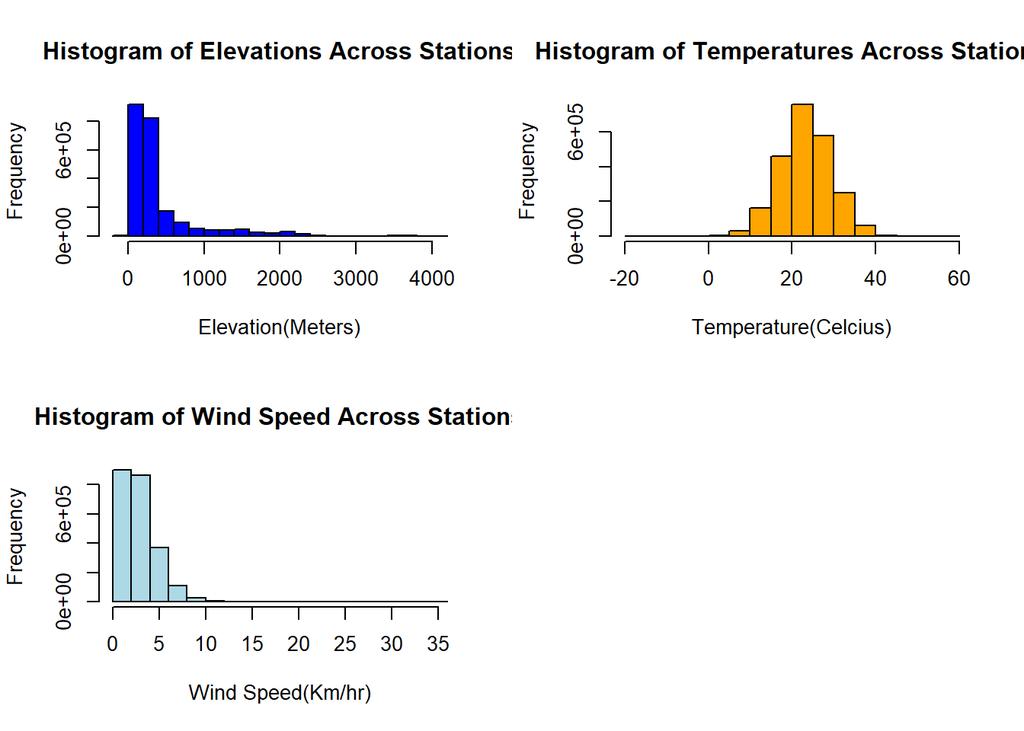

```r
par(mfrow = c(2, 2))

hist(met$elev, main = "Histogram of Elevations Across Stations", xlab = "Elevation(Meters)", col = "blue")
hist(met$temp, main = "Histogram of Temperatures Across Stations", xlab = "Temperature(Celcius)", col = "orange")
hist(met$wind.sp, main = "Histogram of Wind Speed Across Stations", xlab = "Wind Speed(Km/hr)", col = "lightblue")
```

```r
#install.packages("leaflet")
library(leaflet)
leaflet(high_elevation) %>%
  addProviderTiles('OpenStreetMap') %>%
  addCircles(lat=~lat,lng=~lon, opacity=1, fillOpacity=1, radius=100)
```

[interactive chart not shown]

```r
library(lubridate)
high_elevation$date <- with(high_elevation, ymd_h(paste(year, month, day, hour, sep= ' ')))
summary(high_elevation$date)
```

```
                 Min.               1st Qu.                Median
"2019-08-01 00:00:00" "2019-08-08 06:00:00" "2019-08-16 17:00:00"
                 Mean               3rd Qu.                  Max.
"2019-08-16 12:13:41" "2019-08-24 13:00:00" "2019-08-31 22:00:00"
```

```r
elev = high_elevation[order(high_elevation$date), ]
head(elev)
```

```
  USAFID WBAN year month day hour min  lat      lon elev wind.dir wind.dir.qc
1 720385  419 2019     8   1    0  36 39.8 -105.766 4113      170           5
2 720385  419 2019     8   1    0  54 39.8 -105.766 4113      100           5
3 720385  419 2019     8   1    1  12 39.8 -105.766 4113       90           5
4 720385  419 2019     8   1    1  35 39.8 -105.766 4113      110           5
5 720385  419 2019     8   1    1  53 39.8 -105.766 4113      120           5
6 720385  419 2019     8   1    2  12 39.8 -105.766 4113      120           5
  wind.type.code wind.sp wind.sp.qc ceiling.ht ceiling.ht.qc ceiling.ht.method
1              N     8.8          5       1372             5                 M
2              N     2.6          5       1372             5                 M
3              N     3.1          5       1981             5                 M
4              N     4.1          5       2134             5                 M
5              N     4.6          5       2134             5                 M
6              N     6.2          5      22000             5                 9
  sky.cond vis.dist vis.dist.qc vis.var vis.var.qc temp temp.qc dew.point
1        N       NA           9       N          5    9       5         1
2        N       NA           9       N          5    9       5         1
3        N       NA           9       N          5    9       5         2
4        N       NA           9       N          5    9       5         2
5        N       NA           9       N          5    9       5         2
6        N       NA           9       N          5    9       5         2
  dew.point.qc atm.press atm.press.qc       rh                date
1            5        NA            9 57.61039 2019-08-01 00:00:00
2            5        NA            9 57.61039 2019-08-01 00:00:00
3            5        NA            9 61.85243 2019-08-01 01:00:00
4            5        NA            9 61.85243 2019-08-01 01:00:00
5            5        NA            9 61.85243 2019-08-01 01:00:00
6            5        NA            9 61.85243 2019-08-01 02:00:00
```

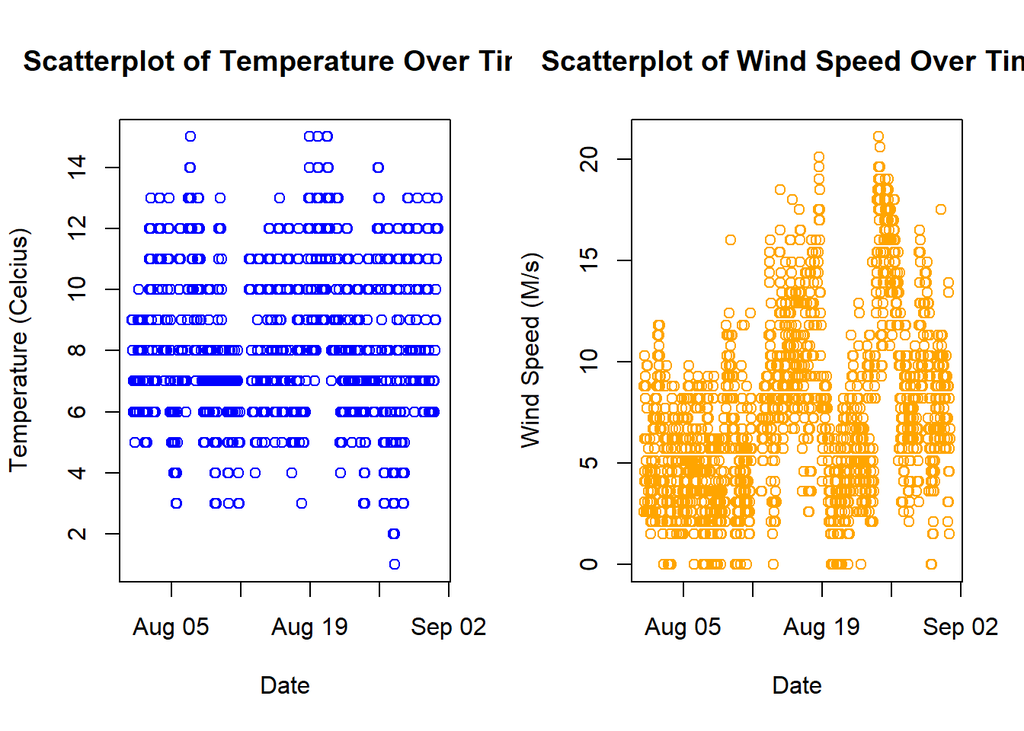

```r
par(mfrow = c(1,2))
plot(elev$date, elev$temp, main = "Scatterplot of Temperature Over Time", xlab = "Date", ylab = "Temperature (Celcius)" , col = "blue")
plot(elev$date, elev$wind.sp, main = "Scatterplot of Wind Speed Over Time", xlab = "Date", ylab = "Wind Speed (M/s)", col = "orange")
```

## Question 8: Further Questions/Exploration

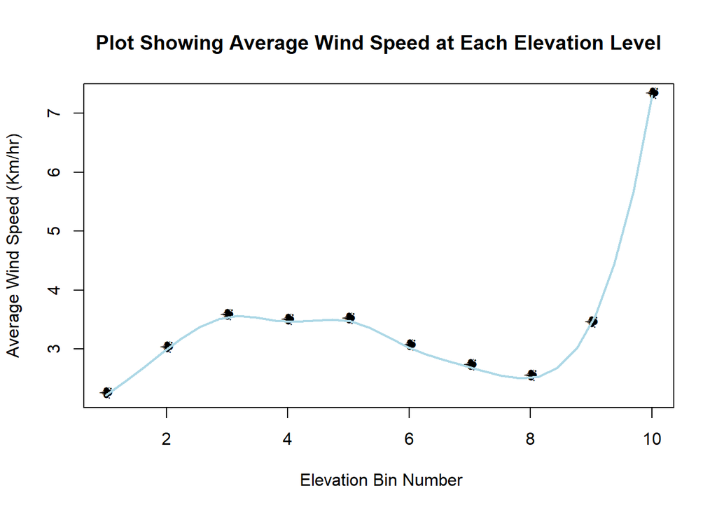

```r
met$elevation_bin = cut(met$elev, breaks = 10, include.lowest = TRUE)
no_na_met = met %>% select(elev, wind.sp, elevation_bin) %>% filter(!is.na(elev), !is.na(wind.sp), !is.na(elevation_bin))
plot_data = no_na_met %>% group_by(elevation_bin) %>% summarize(average_wind_speed = mean(wind.sp, na.rm = T))

x = as.numeric(plot_data$elevation_bin)
y = plot_data$average_wind_speed
plot(x, y, xlab = " Elevation Bin Number", ylab = "Average Wind Speed (Km/hr)", main = "Plot Showing Average Wind Speed at Each Elevation Level", pch = "💨️")
spline_fit = spline(x, y)
lines(spline_fit, col = "lightblue", lwd = 2)
```